# Qualitative Activity Recognition Using Weight Lifting Exercises Dataset

George Chadderdon

July 31, 2016

# Introduction

In this project, we developed a classifier using the Weight Lifting Exercises Dataset provided by (Velloso et al., 2013) at http://groupware.les.inf.puc-rio.br/har. In the data they collected, 6 participants performed sets of dumbbell lifts with one of 5 styles of lifting (A-E). Style A was correct form for the lifts and B-E were specific incorrect methods of lifting the dumbbell. Inertial measurement units (IMUs; 3-axis accelerometer, gyros, and magnetometer) were attached to the lifter’s belt, arm, forearm, and to the dumbbell being lifted. Raw IMU data and features extracted from this data were used to train a classifier for styles A-E.

# Data Processing

First we loaded in the dplyr, caret, and rattle packages:

```r
library(dplyr)
library(caret)
library(rattle)
```

Then, the raw training and test set data were read in:

```r
trainset <- read.csv("pml-training.csv")
testset <- read.csv("pml-testing.csv")
```

We then removed column X (the row indices):

```r
trainset <- select(trainset, -X)
testset <- select(testset, -X)
```

There were a number of feature columns (e.g., `kurtosis_roll_belt`, `max_roll_belt`) which have all missing values, so we excluded these columns:

```r
NAcols <- which(apply(is.na(testset), 2, sum) == 20)
testset <- select(testset, -NAcols)
trainset <- select(trainset, -NAcols)
```

```r
trainset <- select(trainset, -(user_name:num_window))
testset <- select(testset, -(user_name:num_window))
```

We were left with 52 predictor feature columns and, in the training set, a `classe` outcome column:

```r
colnames(trainset)
```

```
##  [1] "roll_belt"            "pitch_belt"           "yaw_belt"
##  [4] "total_accel_belt"     "gyros_belt_x"         "gyros_belt_y"
##  [7] "gyros_belt_z"         "accel_belt_x"         "accel_belt_y"
## [10] "accel_belt_z"         "magnet_belt_x"        "magnet_belt_y"
## [13] "magnet_belt_z"        "roll_arm"             "pitch_arm"
## [16] "yaw_arm"              "total_accel_arm"      "gyros_arm_x"
## [19] "gyros_arm_y"          "gyros_arm_z"          "accel_arm_x"
## [22] "accel_arm_y"          "accel_arm_z"          "magnet_arm_x"
## [25] "magnet_arm_y"         "magnet_arm_z"         "roll_dumbbell"
## [28] "pitch_dumbbell"       "yaw_dumbbell"         "total_accel_dumbbell"
## [31] "gyros_dumbbell_x"     "gyros_dumbbell_y"     "gyros_dumbbell_z"
## [34] "accel_dumbbell_x"     "accel_dumbbell_y"     "accel_dumbbell_z"
## [37] "magnet_dumbbell_x"    "magnet_dumbbell_y"    "magnet_dumbbell_z"
## [40] "roll_forearm"         "pitch_forearm"        "yaw_forearm"
## [43] "total_accel_forearm"  "gyros_forearm_x"      "gyros_forearm_y"
## [46] "gyros_forearm_z"      "accel_forearm_x"      "accel_forearm_y"
## [49] "accel_forearm_z"      "magnet_forearm_x"     "magnet_forearm_y"
## [52] "magnet_forearm_z"     "classe"
```

There were 13 features each for data taken from the belt, arm, forearm, and dumbbell. These included X, Y, Z raw values for the accelerometer, gyro, and magnetometer; roll, pitch, and yaw values; and a measure of total acceleration.

# Predictive Modeling

As an initial try, we used `caret`’s `train()` command to train a CART decision tree on the full training set:

```r
set.seed(1)
fitControl <- trainControl(method="repeatedcv", number=10, repeats=1)
modelFit.cart <- train(classe ~ ., method="rpart", trControl=fitControl,
    data=trainset)
```

This tried 3 values of the `cp` parameter, and for each of these tries, ran 10-fold cross-validation on the full training set. Which `cp` value was chosen was selected based on which cross-validation-averaged accuracy was the largest:

```r
modelFit.cart$results
```

```
##           cp  Accuracy     Kappa AccuracySD    KappaSD
## 1 0.03567868 0.5066757 0.3557230 0.01373015 0.01827635
## 2 0.05998671 0.4162149 0.2088340 0.06431420 0.10827765
## 3 0.11515454 0.3322811 0.0729701 0.04126789 0.06284480
```

Thus, 0.0357 was selected for model parameter `cp`, and this model was trained on the full training set.

The training set accuracy of this tree is poor:

```r
trainPreds.cart <- predict(modelFit.cart, trainset)
CM.cart <- confusionMatrix(trainPreds.cart, trainset$classe)
CM.cart$overall[1]
```

```
##  Accuracy
## 0.4955662
```

```r
CM.cart$table  ## confusion matrix
```

```
##           Reference
## Prediction    A    B    C    D    E
##          A 5080 1581 1587 1449  524
##          B   81 1286  108  568  486
##          C  405  930 1727 1199  966
##          D    0    0    0    0    0
##          E   14    0    0    0 1631
```

To get some idea why the performance is so poor, the architecture of the tree can be viewed using the fancyRpartPlot() function from the `rattle` package:

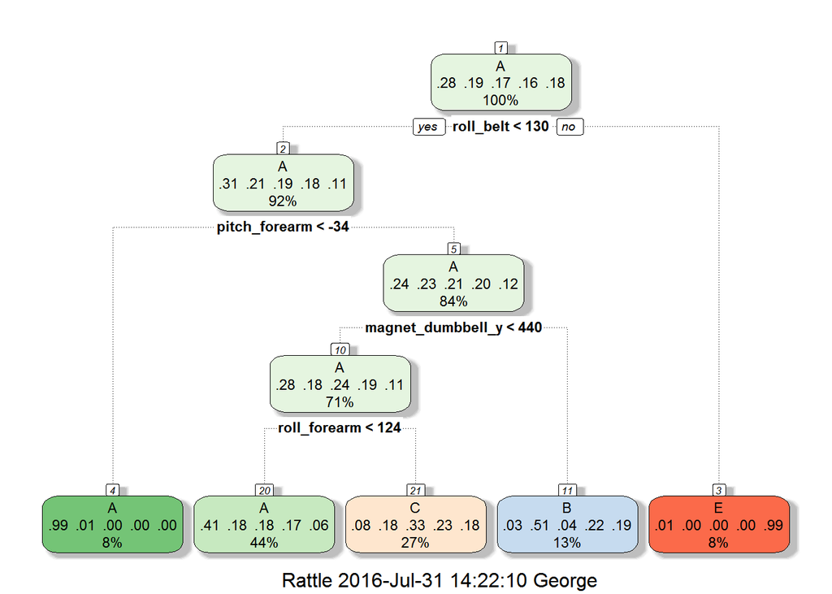

```r
fancyRpartPlot(modelFit.cart$finalModel)
```

One source of the poor accuracy is the failure of the tree to ever return a classification of D, which it could never do because this tree has no leaves that classify as D. Performance is better than chance (accuracy 0.20), however, suggesting that a decision tree-based approach is not entirely infeasible if the right features are used for branch-splitting

With this in mind, a random forest approach was tried so that 500 random decision trees could be implemented and the classification results taken by majority vote on the classification from the individual trees:

```r
set.seed(1)
fitControl <- trainControl(method="repeatedcv", number=10, repeats=1)
modelFit.rf <- train(classe ~ ., method="rf", trControl=fitControl,
    data=trainset)
```

Again, 10-fold cross-validation was used for each parameter (`mtry`) try. The following cross-validation performances were achieved:

```r
modelFit.rf$results
```

```
##   mtry  Accuracy     Kappa   AccuracySD     KappaSD
## 1    2 0.9951584 0.9938755 0.0011080234 0.001401676
## 2   27 0.9948527 0.9934889 0.0008810815 0.001114211
## 3   52 0.9899092 0.9872353 0.0016785928 0.002123823
```

The final model was trained with `mtry` = 2 (2 random feature variables tried at each decision tree node split), and the results were perfect accuracy on the training set:

```r
trainPreds.rf <- predict(modelFit.rf, trainset)
CM.rf <- confusionMatrix(trainPreds.rf, trainset$classe)
CM.rf$overall[1]
```

```
## Accuracy
##        1
```

```r
CM.rf$table  ## confusion matrix
```

```
##           Reference
## Prediction    A    B    C    D    E
##          A 5580    0    0    0    0
##          B    0 3797    0    0    0
##          C    0    0 3422    0    0
##          D    0    0    0 3216    0
##          E    0    0    0    0 3607
```

While perfect accuracy on the training set is no guarantee of perfect accuracy on the withheld testing set, the cross-validation accuracy of 0.995 suggests that the performance on the testing set should be very good because cross-validation does a similar withholding of samples and a good performance on averge of the withheld samples suggests the model will not over-fit the data.

The random forest yielded the following measures of importance for the 52 features:

```r
modelFit.rf$finalModel$importance
```

```
##                      MeanDecreaseGini
## roll_belt                    714.1117
## pitch_belt                   500.9428
## yaw_belt                     634.5507
## total_accel_belt             267.8861
## gyros_belt_x                 169.7139
## gyros_belt_y                 179.0135
## gyros_belt_z                 306.4064
## accel_belt_x                 192.5933
## accel_belt_y                 181.1801
## accel_belt_z                 391.9830
## magnet_belt_x                275.8221
## magnet_belt_y                391.6843
## magnet_belt_z                374.5744
## roll_arm                     333.2746
## pitch_arm                    240.1249
## yaw_arm                      276.2349
## total_accel_arm              171.8313
## gyros_arm_x                  214.5911
## gyros_arm_y                  204.3403
## gyros_arm_z                  118.2850
## accel_arm_x                  296.6407
## accel_arm_y                  220.1931
## accel_arm_z                  199.5353
## magnet_arm_x                 282.3943
## magnet_arm_y                 287.6713
## magnet_arm_z                 234.3377
## roll_dumbbell                378.9012
## pitch_dumbbell               263.0658
## yaw_dumbbell                 295.9827
## total_accel_dumbbell         282.8128
## gyros_dumbbell_x             196.4731
## gyros_dumbbell_y             296.6362
## gyros_dumbbell_z             140.7551
## accel_dumbbell_x             291.7949
## accel_dumbbell_y             393.7729
## accel_dumbbell_z             346.7675
## magnet_dumbbell_x            449.1193
## magnet_dumbbell_y            517.0574
## magnet_dumbbell_z            540.4460
## roll_forearm                 440.4778
## pitch_forearm                490.4159
## yaw_forearm                  224.4850
## total_accel_forearm          178.9054
## gyros_forearm_x              140.0811
## gyros_forearm_y              195.8086
## gyros_forearm_z              145.9555
## accel_forearm_x              320.0524
## accel_forearm_y              215.0897
## accel_forearm_z              253.8194
## magnet_forearm_x             279.5941
## magnet_forearm_y             271.5952
## magnet_forearm_z             286.1650
```

The belt roll measure, the belt yaw measure, the z axis magnetometer measure for the dumbbell appear to be the 3 most important features for classification, as measured by mean decrease of the Gini measure.

The predictions we expect to get for the 20 exemplars in the test set are:

```r
predict(modelFit.rf, testset)
```

```
##  [1] B A B A A E D B A A B C B A E E A B B B
## Levels: A B C D E
```

# Reference

Velloso, E.; Bulling, A.; Gellersen, H.; Ugulino, W.; Fuks, H. Qualitative Activity Recognition of Weight Lifting Exercises. *Proceedings of 4th International Conference in Cooperation with SIGCHI (Augmented Human ’13)*. Stuttgart, Germany: ACM SIGCHI, 2013.